# Coding Assignment 1

Group 7: Kim Dove, Daniel Arbelaez, Anita Gabbard, Mohammad Amori

Due: 2022-09-25 23:59

```r
knitr::opts_chunk$set(echo = TRUE)
```

```r
# Put any packages you want here
library(gt)
library(tidyverse)
library(gtsummary)
```

```r
library(plotly)
library(readxl)
library(plotly)
library(corrplot)
library(dplyr)
library(car)
library(jtools)
```

A Florida health insurance company wants to predict annual claims for individual clients. The company pulls a random sample of 50 customers. The owner wishes to charge an actuarially fair premium to ensure a normal rate of return. The owner collects all of their current customer’s health care expenses from the last year and compares them with what is known about each customer’s plan.

The data on the 50 customers in the sample is as follows:

- Charges: Total medical expenses for a particular insurance plan (in dollars)
- Age: Age of the primary beneficiary
- BMI: Primary beneficiary’s body mass index (kg/m2)
- Female: Primary beneficiary’s birth sex (0 = Male, 1 = Female)
- Children: Number of children covered by health insurance plan (includes other dependents as well)
- Smoker: Indicator if primary beneficiary is a smoker (0 = non-smoker, 1 = smoker)
- Cities: Dummy variables for each city with the default being Sanford

Answer the following questions using complete sentences and attach all output, plots, etc. within this report.

**For this assignment, ignore the categorical variables (gender, smoker, cities)**

```r
# Bring in the dataset here
insurancegroup7 <- read_excel("../Data/insurance_0126_Group7.xlsx")
```

```r
# Custom function created by professor to generate the mode using the "charges" variable
getModes <- function(x) {
  ux <- unique(x)
  tab <- tabulate(match(x, ux))
  ux[tab == max(tab)]
}
```

# Question 1

Perform univariate analyses on the quantitative variables (center, shape, spread). Include descriptive statistics, and histograms. Be sure to use terms discussed in class such as bimodal, skewed left, etc.

```r
# ************************************* CHARGES  *************************************

# Adding the Charges column to the "Charges" variable
Charges <- (insurancegroup7$Charges)
# Summary of descriptive statistics including Mean, Median, IQR, Min, Max
summary(Charges)
```

```
##    Min. 1st Qu.  Median    Mean 3rd Qu.    Max.
##    1147    4144    9820   15132   20372   58571
```

```r
#Standard Deviation
sd(Charges)
```

```
## [1] 14569.33
```

```r
# Using the custom function from the professor to get the mode of the Charges column using the "charges" variable
getModes(Charges)
```

```
##  [1]  8965.796  2850.684 38511.628  9850.432 37270.151 47055.532 27218.437
##  [8]  1146.797  2523.169 39774.276  6555.070  5261.469 11658.115  4466.621
## [15] 41661.602 19144.577  9880.068  7935.291  8930.935 14001.287 34828.654
## [22] 17128.426  2689.495  3277.161 18903.491  9788.866  6548.195 12957.118
## [29]  4058.116  4402.233 12347.172  6059.173 12333.828 12323.936 58571.074
## [36]  1261.859 36189.102  8671.191  1837.237  1149.396  2494.022  9144.565
## [43] 22412.648  2138.071  2719.280 40273.645 20781.489 34303.167 10231.500
## [50]  2136.882
```

```r
IQR(Charges)
```

```
## [1] 16228.12
```

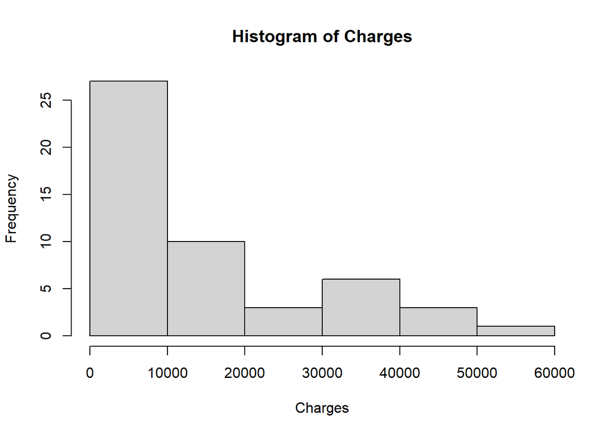

```r
# Generate a histogram of the Charges column using the "charges" variable
hist(Charges)
```

```r
# ************************************* Age  *************************************

Age <- (insurancegroup7$Age)
summary(Age)
```

```
##    Min. 1st Qu.  Median    Mean 3rd Qu.    Max.
##   18.00   24.00   36.00   37.56   51.75   63.00
```

```r
sd(Age)
```

```
## [1] 14.81196
```

```r
getModes(Age)
```

```
## [1] 19
```

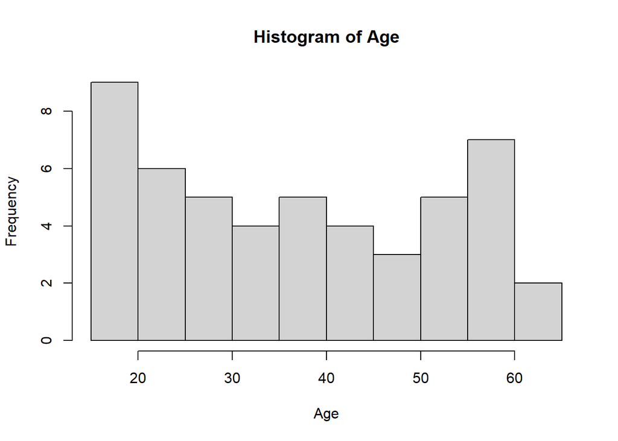

```r
hist(Age)
```

Mean: 37.56  
Median: 36.00  
Mode: Bimodal  
Std Deviation: 14.81196  
Histogram: Bimodal, two peaks  
Measure of center: Mean  
Measure of spread: Since the Mean is the measure of center the best measure of spread will be the standard deviation (14.81196)

```r
# ************************************* BMI  *************************************

BMI <- (insurancegroup7$BMI)
summary(BMI)
```

```
##    Min. 1st Qu.  Median    Mean 3rd Qu.    Max.
##   19.95   28.69   32.11   32.33   36.65   43.01
```

```r
sd(BMI)
```

```
## [1] 5.150382
```

```r
getModes(BMI)
```

```
## [1] 36.670 28.595 37.100 36.575
```

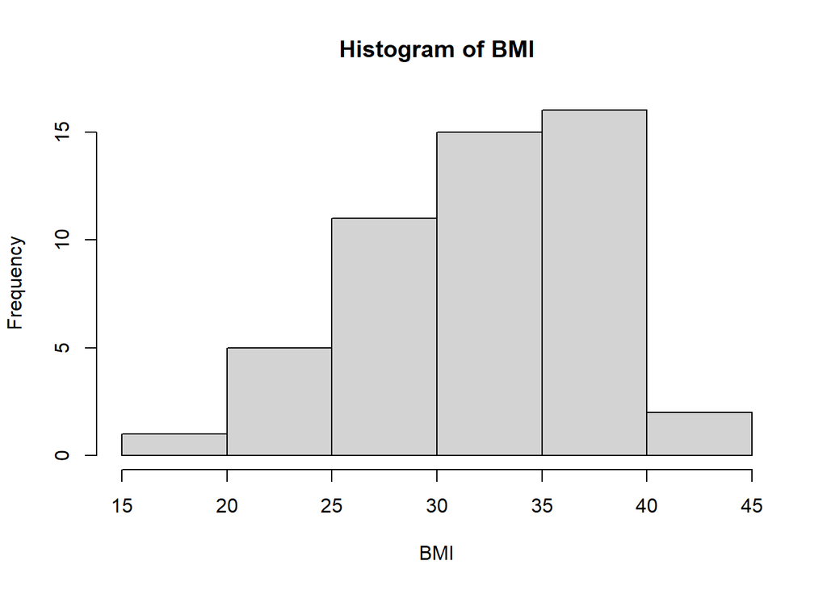

```r
hist(BMI)
```

```r
# ************************************* Children  *************************************

Children <- (insurancegroup7$Children)
summary(Children)
```

```
##    Min. 1st Qu.  Median    Mean 3rd Qu.    Max.
##    0.00    0.00    1.00    1.06    1.75    5.00
```

```r
sd(Children)
```

```
## [1] 1.391079
```

```r
getModes(Children)
```

```
## [1] 0
```

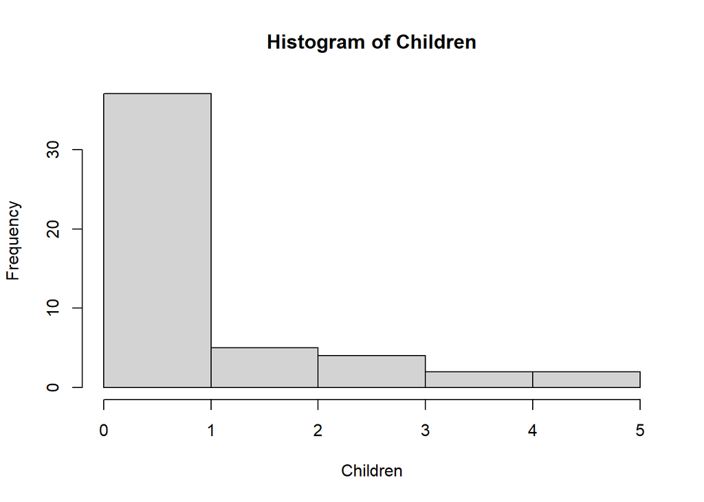

```r
hist(Children)
```

```r
IQR(Children)
```

```
## [1] 1.75
```

Mean: 1.06  
Median: 1.00  
Mode: 0  
Std Deviation:1.391079  
Histogram: Skewed right  
Measure of center: Median  
Measure of spread: IQR (1.75)

# Question 2

Perform bivariate analyses on the quantitative variables (direction, strength and form). Describe the linear association between all variables.

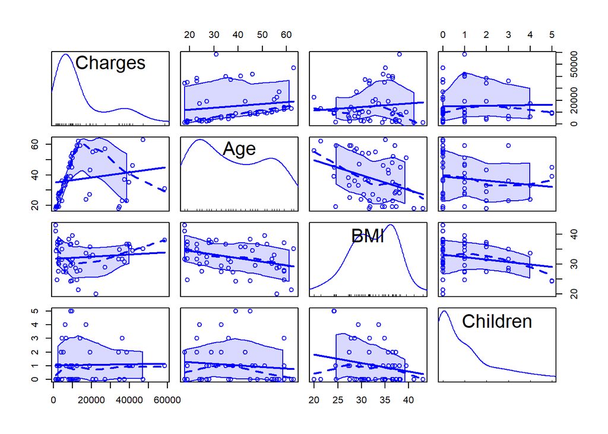

```r
#use cor and scatterplot function
data <- data.frame(Charges, Age, BMI, Children)
scatterplotMatrix(data)
```

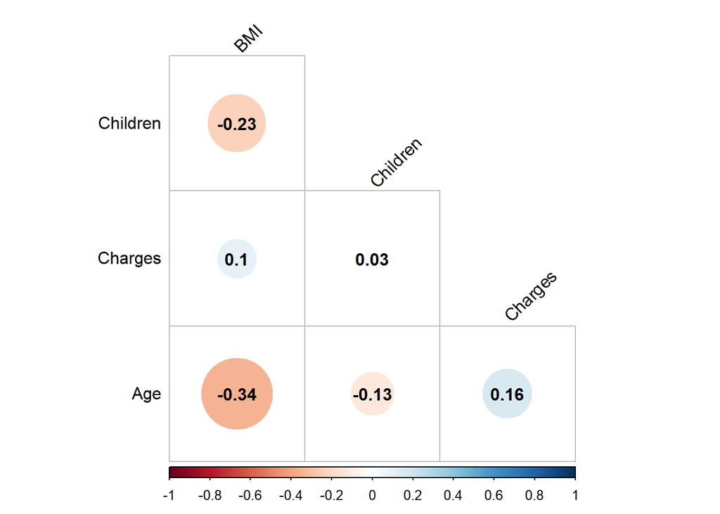

```r
corrplot(cor(data),
         type = "lower",order = "hclust",
         tl.col = "black",
         tl.srt = 45,
         addCoef.col = "black",
         diag = FALSE,)
```

None of the variables observe any strong positive or negative relationships, only weak linear relationships. The most significant relationship is between Age and BMI with a -.34 correlation. The correlation coefficient “r” measures the strength of a relationship and is always a number between -1 and 1, values less than .3 = none or very week relationship, values between 0.3 and 0.5 = weak relationship, values between 0.5 and 0.7 = moderate relationship, values greater than 0.7 = strong relationship, values = +/- 1 = perfect linear relationship. Correlation provides insight into the relationship between variables and is NOT causation.

# Question 3

Generate a regression equation in the following form:

$$Charges =
\beta_{0}+\beta_{1}*Age+\beta_{2}*BMI+\beta_{3}*Children$$

```r
model_Charges <- lm(Charges~Age + BMI + Children, data = insurancegroup7)
model_Charges
```

```
##
## Call:
## lm(formula = Charges ~ Age + BMI + Children, data = insurancegroup7)
##
## Coefficients:
## (Intercept)          Age          BMI     Children
##    -14771.8        246.9        601.1       1129.4
```

```r
summary(model_Charges)
```

```
##
## Call:
## lm(formula = Charges ~ Age + BMI + Children, data = insurancegroup7)
##
## Residuals:
##    Min     1Q Median     3Q    Max
## -14378  -9704  -6198   5337  41658
##
## Coefficients:
##             Estimate Std. Error t value Pr(>|t|)
## (Intercept) -14771.8    18228.8  -0.810    0.422
## Age            246.9      153.0   1.614    0.113
## BMI            601.1      448.3   1.341    0.187
## Children      1129.4     1571.8   0.719    0.476
##
## Residual standard error: 14530 on 46 degrees of freedom
## Multiple R-squared:  0.06603,    Adjusted R-squared:  0.005115
## F-statistic: 1.084 on 3 and 46 DF,  p-value: 0.3653
```

```r
summ(model_Charges)
```

```
## MODEL INFO:
## Observations: 50
## Dependent Variable: Charges
## Type: OLS linear regression
##
## MODEL FIT:
## F(3,46) = 1.08, p = 0.37
## R² = 0.07
## Adj. R² = 0.01
##
## Standard errors: OLS
## --------------------------------------------------------
##                          Est.       S.E.   t val.      p
## ----------------- ----------- ---------- -------- ------
## (Intercept)         -14771.80   18228.76    -0.81   0.42
## Age                    246.95     153.04     1.61   0.11
## BMI                    601.12     448.26     1.34   0.19
## Children              1129.43    1571.83     0.72   0.48
## --------------------------------------------------------
```

also write out the regression cleanly in this document.

$$Multiple Linear Regression for Charges
= -14772 + 247*Age + 601*BMI + 1129*Children$$

# Question 4

An eager insurance representative comes back with a potential client. The client is 40, their BMI is 30, and they have one dependent. Using the regression equation above, predict the amount of medical expenses associated with this policy. (Provide a 95% confidence interval as well)

```r
newPrediction <- data.frame(Age = 40, BMI = 30, Children = 1)
predict(model_Charges, newdata = newPrediction, interval = "confidence")
```

```
##        fit      lwr      upr
## 1 14269.15 9678.641 18859.66
```

A person of age 40 with a BMI of 30 and 1 child will have medical expenses around $14,269.15. Using a 95% confidence interval the prediction has a lower limit of $9,678.64 and an upper limit of $18,859.66.